# testing siber with text labels for groups and communities

Andrew L Jackson

13 March, 2025

And now the full code…

```r
# rm(list = ls()) # clear the memory of objects

# load the siar package of functions
library(SIBER)

# read in the data
# read in the data
mydata <- read.csv("../data/example_layman_data_all.csv",
                   header=TRUE)

# create the siber object
siber.example <- createSiberObject(mydata)

# Create lists of plotting arguments to be passed onwards to each
# of the three plotting functions.
community.hulls.args <- list(col = 1, lty = 1, lwd = 1)
group.ellipses.args  <- list(n = 100, p.interval = 0.95,
                             lty = 1, lwd = 2,
                             small.sample = TRUE)
group.hull.args      <- list(lty = 2, col = "grey20")


# ellipses and group.hulls are set to TRUE or T for short to force
# their plotting.
par(mfrow=c(1,1))
plotSiberObject(siber.example,
                  ax.pad = 2,
                  hulls = FALSE, community.hulls.args,
                  ellipses = TRUE, group.ellipses.args,
                  group.hulls = TRUE, group.hull.args,
                  bty = "L",
                  iso.order = c(1,2),
                  xlab = expression({delta}^13*C~'\u2030'),
                  ylab = expression({delta}^15*N~'\u2030')
                  )


# You can add more ellipses by directly calling plot.group.ellipses()
# Add an additional p.interval % prediction ellilpse
plotGroupEllipses(siber.example, n = 100, p.interval = 0.50,
                    lty = 1, lwd = 2, small.sample = TRUE)
```

```r
# or you can add the XX% confidence interval around the bivariate means
# by specifying ci.mean = T along with whatever p.interval you want.
plotGroupEllipses(siber.example, n = 100, p.interval = 0.95,
                  ci.mean = TRUE, lty = 1, lwd = 2)


# Calculate sumamry statistics for each group: TA, SEA and SEAc
group.ML <- groupMetricsML(siber.example)
print(group.ML)
```

```
           1.1      1.2      1.3      1.4      2.1      2.2      2.3      2.4
TA   1.5555360 14.86029 84.20837 43.81102 4.552414 2.952808 4.434037 2.889293
SEA  0.5412062  5.35464 33.73813 15.87191 2.526144 1.666699 2.733655 1.873229
SEAc 0.5712732  5.65212 35.61247 16.75368 2.947168 1.944482 3.189264 2.185434
```

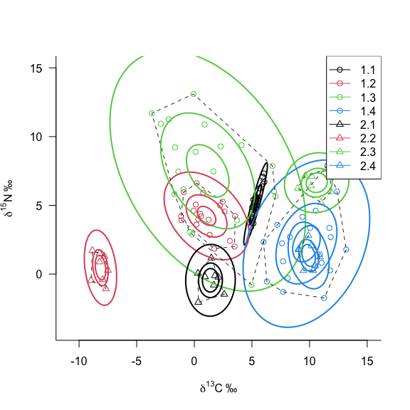

```r
# add a legend
legend("topright", colnames(group.ML),
       pch = c(1,1,1,1,2,2,2,2), col = c(1:4, 1:4), lty = 1)
```

## Using Bayesian Inference to calculate uncertainty around ellipses

So far these still just point-metrics that describe the width of the isotopic niche. That is, they are single numbers for each group, which means that we can’t compare one group to another in a statisical sense as we lack a measure of the uncertainty around each estimate. This is where we can use Bayesian Inference to quantify the error associated with fitting these ellipses to each group, that arises from both the number of samples we have, and also their distribution.

Essentially, what the MCMC algorithm does is generate a distribution of covariance matrices that to a greater or lesser extent (in terms of likelihood) describe the observed data. It does so, as is the general case in Bayesian Inference, by combing the prior probability with the likelihood of the data for a given covariance matrix.

SIBER uses the jags package to fit the Bayesian model and so we need to specify the parameters of the simulation run, including: run length, burn-in period, number of chains etc…

```r
# options for running jags
parms <- list()
parms$n.iter <- 2 * 10^4   # number of iterations to run the model for
parms$n.burnin <- 1 * 10^3 # discard the first set of values
parms$n.thin <- 10     # thin the posterior by this many
parms$n.chains <- 2        # run this many chains

# define the priors
priors <- list()
priors$R <- 1 * diag(2)
priors$k <- 2
priors$tau.mu <- 1.0E-3

# fit the ellipses which uses an Inverse Wishart prior
# on the covariance matrix Sigma, and a vague normal prior on the
# means. Fitting is via the JAGS method.
ellipses.posterior <- siberMVN(siber.example, parms, priors)
```

[output not shown]

[output cut: 366 more lines]

[output not shown]

What we end up with is a range of ellipses that could explain the data, with more of them clustered around the most likely solution. However, one cannot simply take an average across these covariance matrices, as there are strict mathematical properties that must be maintained. The result of this is that it is not possible to plot a mean, median or modal Bayesian Standard Ellipse; instead we must calculate each one of the ellipse’s area, and then present summary statistics of this derived measurement. SIBER contains a function that will automatically loop over all the groups and do this.

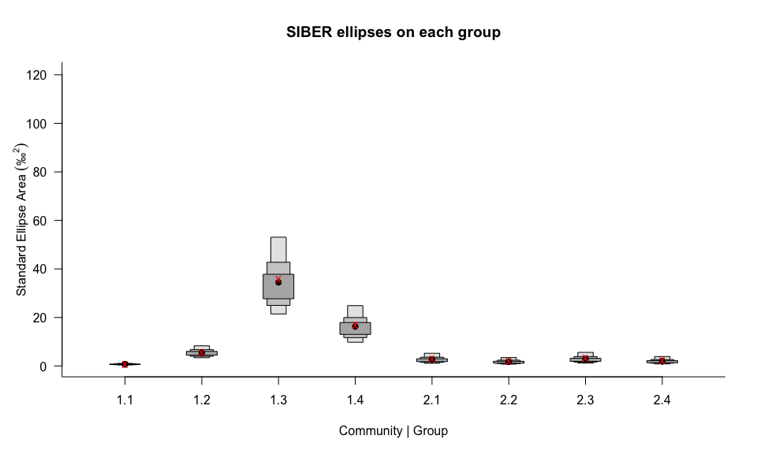

```r
#
# ----------------------------------------------------------------
# Plot out some of the data and results
# ----------------------------------------------------------------

# The posterior estimates of the ellipses for each group can be used to
# calculate the SEA.B for each group.
SEA.B <- siberEllipses(ellipses.posterior)

siberDensityPlot(SEA.B, xticklabels = colnames(group.ML),
                xlab = c("Community | Group"),
                ylab = expression("Standard Ellipse Area " ('\u2030' ^2) ),
                bty = "L",
                las = 1,
                main = "SIBER ellipses on each group",
                ct = "median"
                )

# Add red x's for the ML estimated SEA-c
points(1:ncol(SEA.B), group.ML[3,], col="red", pch = "x", lwd = 2)
```

```r
# Calculate some credible intervals
cr.p <- c(0.95, 0.99) # vector of quantiles

# call to hdrcde:hdr using lapply()
SEA.B.credibles <- lapply(
  as.data.frame(SEA.B),
  function(x,...){tmp<-hdrcde::hdr(x)$hdr},
  prob = cr.p)

print(SEA.B.credibles)
```

```
$V1
         [,1]      [,2]
99% 0.3677928 1.2430590
95% 0.4282264 1.0766122
50% 0.5796244 0.7908757

$V2
        [,1]     [,2]
99% 2.900940 9.571018
95% 3.314925 8.250329
50% 4.455694 6.020916

$V3
        [,1]     [,2]
99% 16.52250 61.10344
95% 20.21876 52.32721
50% 28.19991 38.35680

$V4
         [,1]     [,2]
99%  7.483162 29.62652
95%  9.329865 24.69192
50% 13.203692 18.07801

$V5
         [,1]     [,2]
99% 0.7998808 6.996652
95% 1.0779314 5.209890
50% 1.7955421 2.987811

$V6
         [,1]     [,2]
99% 0.5579949 4.576322
95% 0.7452355 3.441999
50% 1.1565550 1.952475

$V7
         [,1]     [,2]
99% 0.8693402 7.539435
95% 1.1216733 5.570262
50% 1.9198139 3.190130

$V8
         [,1]     [,2]
99% 0.5881199 5.101565
95% 0.8075091 3.858934
50% 1.3359565 2.203380
```

```r
# do similar to get the modes, taking care to pick up multimodal posterior
# distributions if present
SEA.B.modes <- lapply(
  as.data.frame(SEA.B),
  function(x,...){tmp<-hdrcde::hdr(x)$mode},
  prob = cr.p, all.modes=T)

print(SEA.B.modes)
```

```
$V1
[1] 0.6790726

$V2
[1] 5.171671

$V3
[1] 32.9267

$V4
[1] 15.49167

$V5
[1] 2.267964

$V6
[1] 1.492184

$V7
[1] 2.474116

$V8
[1] 1.722239
```

## Comparing the posterior distributions

In order to test whether one group’s ellipse is smaller or larger than another, we can simply calculate the probability that its posterior distribution is smaller (or larger). This is acheived by comparing each pair of posterior draws for both groups, and dtermining which is smaller in magnitude. We then find the proportion of draws that are smaller, and this is a direct proxy for the probability that one group’s posterior distribution (of ellipse size in this case) is smaller than the other.

Here, we first calculate the proportion, and hence probability, of the SEA.B for group 1 being smaller than the SEA.B for group 2.

```r
Pg1.lt.g2 <- sum( SEA.B[,1] < SEA.B[,2] ) / nrow(SEA.B)
print(Pg1.lt.g2)
```

```
[1] 1
```

So, in this case, all of the estimates for groups 1’s ellipse are smaller than for group 2; although we could probably guess at this given that there appears to be no overlap between then 95% credible intervals of the two groups (see the figure above).

Then we can do exactly the same for groups 1 and 3.

```r
Pg1.lt.g3 <- sum( SEA.B[,1] < SEA.B[,3] ) / nrow(SEA.B)
print(Pg1.lt.g3 )
```

```
[1] 1
```

And then for the other pairings:

```r
Pg1.lt.g4 <- sum( SEA.B[,1] < SEA.B[,4] ) / nrow(SEA.B)
print(Pg1.lt.g4)
```

```
[1] 1
```

```r
Pg2.lt.g3 <- sum( SEA.B[,2] < SEA.B[,3] ) / nrow(SEA.B)
print(Pg2.lt.g3)
```

```
[1] 1
```

```r
Pg3.lt.g4 <- sum( SEA.B[,3] < SEA.B[,4] ) / nrow(SEA.B)
print(Pg3.lt.g4)
```

```
[1] 0.01125
```

```r
Pg5.lt.g7 <- sum( SEA.B[,5] < SEA.B[,7] ) / nrow(SEA.B)
print(Pg5.lt.g7)
```

```
[1] 0.54675
```

## Overlap Between Ellipses

One can calculate the overlap between two (or more) ellipses. In the first instance, this overlap is simply the area, in units of per mil squared, contained by the shape that lies within the overlapping region. This overlap is most easily calculated by using the SEAc of each ellipse.

The overlap between the SEAc for groups 3 and 4 in Community 1 is given by:

```r
overlap.G3.G4 <- maxLikOverlap("1.3", "1.4", siber.example, p = 0.95, n =100)
```

And the overlap between SEAc of groups 1.2 and 2.1 is given by:

```r
overlap.C1G2.C2G1 <- maxLikOverlap("1.2", "2.1", siber.example, p = 0.95, n = 100)
```

One might then wish to calculate the proportion overlap; athough one then runs into a choice as to what the demoninator will be in the equation. You could for instance calculate the proportion of A that overlaps with B, the proporiton of B that overlaps with A, or the proportion of A and B that overlap with each other.

```r
prop.of.first <- as.numeric(overlap.G3.G4["overlap"] / overlap.G3.G4["area.1"])
print(prop.of.first)
```

```
[1] 0.1506049
```

```r
prop.of.second <- as.numeric(overlap.G3.G4["overlap"] / overlap.G3.G4["area.2"])
print(prop.of.second)
```

```
[1] 0.3201333
```

```r
prop.of.both <- as.numeric(overlap.G3.G4["overlap"] / (overlap.G3.G4["area.1"] + overlap.G3.G4["area.2"]))
print(prop.of.both)
```

```
[1] 0.1024213
```

```r
prop.of.both.less.overlap <- as.numeric(overlap.G3.G4["overlap"] / (overlap.G3.G4["area.1"] + overlap.G3.G4["area.2"] - overlap.G3.G4["overlap"]))
print(prop.of.both.less.overlap)
```

```
[1] 0.1141085
```

A problem with this simple overlap calculation is that it yields a point-estimate of overlap based on the maximum likelihood estimated SEA_c. One can instead calculate a distribution of overlap based on the posterior distirbutions of the fitted ellipses. It can be a bit slow to calculate this overlap, so you may want to drop the number of `draws` if your computer is slow.

```r
bayes.overlap.G3.G4 <- bayesianOverlap("1.3", "1.4",
                                       ellipses.posterior,
                                       draws = 100,
                                       p.interval = 0.95,
                                       n = 360)
print(bayes.overlap.G3.G4)
```

| area1 | area2 | overlap |
| --- | --- | --- |
| 175.0722 | 99.11661 | 26.53453 |
| 237.0295 | 92.92288 | 39.42798 |
| 210.6611 | 66.45333 | 22.82200 |
| 160.6711 | 101.52572 | 4.92107 |
| 185.0463 | 91.66407 | 13.82501 |
| 192.2857 | 90.22134 | 14.73732 |
| 208.0272 | 142.33665 | 32.36122 |
| 160.0049 | 89.84963 | 10.03801 |
| 142.7353 | 128.61938 | 23.84308 |
| 204.8066 | 99.09560 | 15.36281 |

[output cut: 90 more lines]

```r
NA
NA
```

And summarise the credible intervals of the Bayesian overlap output. Note that this code does not work well on the small number of posterior draws we are using for this basic example - for one it returns negative values which is not possible, but is arising as the smoother has not got enough information to stay close to or within the positive number range.

```r
# and we can calculate the corresponding credible intervals using
# our code from above again
# call to hdrcde:hdr using lapply()
overlap.credibles <- lapply(
  as.data.frame(bayes.overlap.G3.G4),
  function(x,...){tmp<-hdrcde::hdr(x)$hdr},
  prob = cr.p)

print(overlap.credibles)
```

```
$area1
         [,1]     [,2]
99%  86.48869 326.7752
95% 119.41736 287.8108
50% 167.58476 234.0323

$area2
        [,1]     [,2]
99% 44.72448 157.4440
95% 57.70316 138.4100
50% 80.55859 108.0818

$overlap
         [,1]     [,2]
99% -9.264529 81.17949
95%  1.018277 60.51250
50% 17.235467 34.21211
```